# 2. Building the model to classify electronic medical records (EMR)

In the batch data processing using HHBatchDataProcessing.ipynb, I have prepared a dataset by extracting medical records that had medical speciality of the following categories on the MTSamples data. Those records have been passed through Comprehend Medical to extract medical key workds and the data is converted to a flat file having the feature set and the label.

```
1: "Cardiovascular / Pulmonary"
2: "Orthopedic"
3: "Radiology"
4: "General Medicine"
5: "Gastroenterology"
6: "Neurology"
```

In this notebook, I will be using the extracted dataset to create a classification model.

The goal of this experiment is to do a **Next step Prediction** which aims at predicting the speciality needed for a patient with certain diseases. In practice, the model could be used to analyze a medical transcription in real-time that can be used to provide a recommended referals to respective specialist, provide medical information related to health condition, provide nutrition or suppliments, exercises or available therapies that can help to improve quality of life and life style decisions. In this way it can establish a portal to integrate health care providers to the patients.

The input for the prediction is the EMR as a pdf file with doctor's notes about the patient or patients notes about their illness described in free form. This unstructured free form text is passed through Comprehend Medical to extract the medical terms which can then be used to predict medical speciality using the trained model.

## Objective

Predict health condition according to the EMR

Input: Free text of patients health condition written by the patient, a prescription or a doctors transcript.

Final goal: According to the predicted Health speciality, provide information about health recommendations and medical speciality. (this programe is ending at the prediciton state but during a product implementation it can be integrated to a health care provider database which can provide information about illnesse, doctors list, nutrition or suppliment list, therapies etc.)

Challenges:

- Dataset is limited and a larger dataset will help to train the model with more accuracy.
- Dataset contains limited amount of health conditions.

## Setup Environment

- **import** some useful libraries (as in any Python notebook)
- **configure** the S3 bucket and folder where data should be stored (to keep our environment tidy)
- **connect** to AWS in general (with [boto3](https://boto3.amazonaws.com/v1/documentation/api/latest/index.html)) and SageMaker in particular (with the [sagemaker SDK](https://sagemaker.readthedocs.io/en/stable/)), to use the cloud services
- **Upgrade** SageMaker to the latest version

```python
pip install --upgrade sagemaker
```

```
     |████████████████████████████████| 577 kB 22.3 MB/s
  Preparing metadata (setup.py) ... done
  Attempting uninstall: sagemaker
    Found existing installation: sagemaker 2.110.0
    Uninstalling sagemaker-2.110.0:
      Successfully uninstalled sagemaker-2.110.0
```

```python
pip install textract-trp
```

```python
import numpy as np  # For matrix operations and numerical processing
import pandas as pd  # For munging tabular data
pd.set_option('display.max_colwidth', None)

import time
import os

# reuse frunctions from medical document processing notebooks
#from util.classification_report import generate_classification_report, predict_from_numpy_V2  # helper function for classification reports
from util.Pipeline import extractTextract, extractMedical
from util.preprocess import *

# import record processing functions
from sklearn.model_selection import train_test_split
from sagemaker.amazon.amazon_estimator import RecordSet

# setting up SageMaker parameters
import pkg_resources
pkg_resources.require("sagemaker>2.9.2")
import sagemaker
import boto3
from sagemaker.image_uris import retrieve

from sklearn.metrics import classification_report

import matplotlib.pyplot as plt
import seaborn as sns

boto_session = boto3.Session()
region = boto_session.region_name
bucket_name = sagemaker.Session().default_bucket()
bucket_prefix = "emr-mtSample"  # Location in the bucket to store our files
sgmk_session = sagemaker.Session()
sgmk_client = boto_session.client("sagemaker")
sgmk_role = sagemaker.get_execution_role()
```

## Load and Explore Dataset

Load the dataset prepared from the previous notebook BatchDataProcessing. This dataset contains labelled data based on the medical speciality selected above and the medical features that were extracted from the electronic medical reports.

You can find the processed dataset in the following location '/data/processed_combined_extract.csv'.

*Demographics:*

- `ID`: id of the patients (int)
- `Label`: the medical condition (1-6 chosen categories)
- The rest of the columns e.g. `fever`, `wheezing`: medical condition extracted from notes. The number indicate confidence of the symptom (float), there are 113 features in this dataset.

```python
df_wide_full=pd.read_csv("./data/processed_combined_extract.csv")
df_wide_full.head()
```

|  | ID | Label | symptoms | hydronephrosis | warm | soft | adenopathy | distress | alert | nausea | ... | diarrhea | cough | diabetes | afebrile | dilated | complications | mass | orthopnea | myocardial infarction | fractures |
| --- | --- | --- | --- | --- | --- | --- | --- | --- | --- | --- | --- | --- | --- | --- | --- | --- | --- | --- | --- | --- | --- |
| 0 | 3 | 1 | 0.0 | 0.0 | 0.0 | 0.0 | 0.0 | 0.0 | 0.000000 | 0.0 | ... | 0.0 | 0.000000 | 0.000000 | 0.0 | 0.000000 | 0.000000 | 0.000000 | 0.0 | 0.0 | 0.0 |
| 1 | 11 | 1 | 0.0 | 0.0 | 0.0 | 0.0 | 0.0 | 0.0 | 0.000000 | 0.0 | ... | 0.0 | 0.000000 | 0.000000 | 0.0 | 0.000000 | 0.000000 | 0.000000 | 0.0 | 0.0 | 0.0 |
| 2 | 16 | 1 | 0.0 | 0.0 | 0.0 | 0.0 | 0.0 | 0.0 | 0.000000 | 0.0 | ... | 0.0 | 0.000000 | 0.000000 | 0.0 | 0.000000 | 0.000000 | 0.000000 | 0.0 | 0.0 | 0.0 |
| 3 | 4577 | 1 | 0.0 | 0.0 | 0.0 | 0.0 | 0.0 | 0.0 | 0.999397 | 0.0 | ... | 0.0 | 0.998593 | 0.969733 | 0.0 | 0.861931 | 0.000000 | 0.998362 | 0.0 | 0.0 | 0.0 |
| 4 | 4579 | 1 | 0.0 | 0.0 | 0.0 | 0.0 | 0.0 | 0.0 | 0.000000 | 0.0 | ... | 0.0 | 0.000000 | 0.000000 | 0.0 | 0.000000 | 0.900658 | 0.000000 | 0.0 | 0.0 | 0.0 |

5 rows × 115 columns

#### Explore correlation between the input variables and output

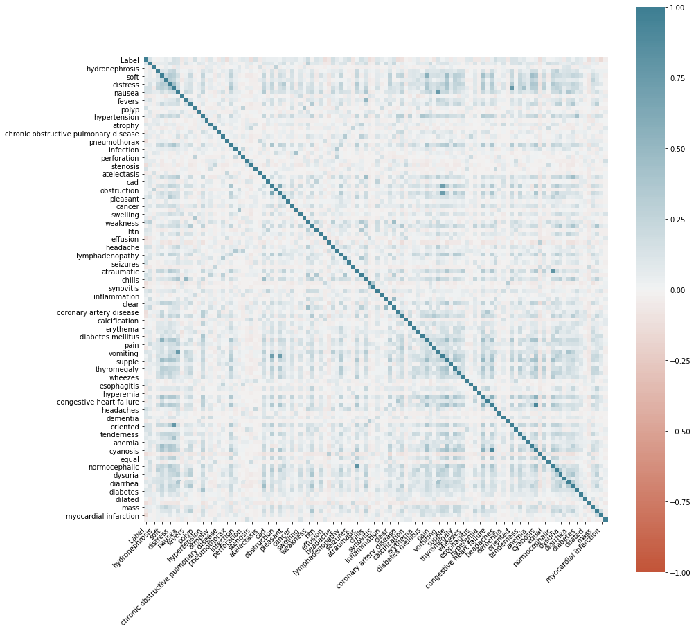

```python
corrPlot(df_wide_full)
```

## Prepare-Dataset-for-Model-Training

1. Convert Label to start from 0 than 1 as required in linear learner.
2. Suffle and split the data into **Training (80%)**, **Validation (10%)**, and **Test (10%)** sets.
3. Visualize data to see the number of records per category.

The training and validation datasets will be used during the training (and tuning) phase, while the 'holdout' test set will be used afterwards to evaluate the model.

```python
# use AWS classifier - linear learner multi classifier

# transform labels to 0 index as it is required by linear learner to have labels starting 0
df_wide_full['Label'] -= 1

df_wide_full=df_wide_full.apply(pd.to_numeric, downcast='float', errors='coerce')

# remove the id column and drop label for X dataset
X=df_wide_full.drop(['Label', 'ID'], axis=1)
y=df_wide_full['Label'] # chose Label for y dataset

# shuffle and split into train and test sets
np.random.seed(0)
train_features, test_features, train_labels, test_labels = train_test_split(X, y, test_size=0.2)
# further split the test set into validation and test sets
val_features, test_features, val_labels, test_labels = train_test_split(
    test_features, test_labels, test_size=0.5
)
```

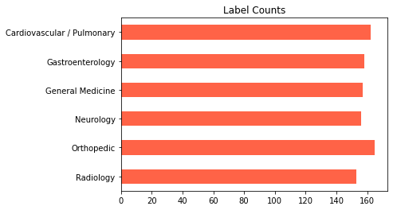

```python
# Visualize data
# assign label names and count label frequencies

label_map = {
    0: "Cardiovascular / Pulmonary",
    1: "Orthopedic",
    2: "Radiology",
    3: "General Medicine",
    4: "Gastroenterology",
    5: "Neurology",
}

label_counts = (
    train_labels.map(label_map).value_counts(sort=False).sort_index(ascending=False)
)

label_counts.plot(kind="barh", color="tomato", title="Label Counts")
```

## Linear learner Algorithm

### Define Hyperparameters & Algorithm

Use the [sagemaker.estimator.Estimator()](https://sagemaker.readthedocs.io/en/v1.72.0/api/training/estimators.html) function to configure the parameters.

```python
# instantiate the LinearLearner estimator object
multiclass_estimator = sagemaker.LinearLearner(
    role=sagemaker.get_execution_role(), # IAM role to be used
    train_instance_count=1,
    train_instance_type="ml.m4.xlarge",
    predictor_type="multiclass_classifier",
    num_classes=8,
    epochs= 50,
    num_models = 32,               # max models to test is 32
    max_run=20*60,                 # Maximum allowed active runtime
    max_wait=30*60,                # Maximum clock time (including spot delays)
    use_spot_instances=True,       # Use spot instances to reduce cost
)
```

```
WARNING:sagemaker.deprecations:train_instance_count has been renamed in sagemaker>=2.
See: https://sagemaker.readthedocs.io/en/stable/v2.html for details.
WARNING:sagemaker.deprecations:train_instance_type has been renamed in sagemaker>=2.
See: https://sagemaker.readthedocs.io/en/stable/v2.html for details.
```

```python
# LL - wrap data in RecordSet objects as required by linear learner
train_records = multiclass_estimator.record_set(train_features.values, train_labels.values, channel="train")
val_records = multiclass_estimator.record_set(val_features.values, val_labels.values, channel="validation")
test_records = multiclass_estimator.record_set(test_features.values, test_labels.values, channel="test")
```

## Train-the-Model

To start the training job call the `estimator.fit()` function. This will start a Sagemaker training job in the background. The training job status can be seen within the AWS console by going to Sagemaker -> Training jobs.

Once the training job is completed, proceed to the next step.

```python
# LL - start a training job
multiclass_estimator.fit([train_records, val_records, test_records])
```

[output not shown]

[output cut: 1785 more lines]

[output not shown]

## Deploy and Evaluate the Model

After trainin the model, proceed with deploying the model (hosting it behind a real-time endpoint) so that we can start running predictions in real-time. This can be done using the `estimator.deploy()` function. (https://docs.aws.amazon.com/sagemaker/latest/dg/how-it-works-deployment.html.)

This deployment might take few minutes, and by default the code will wait for the deployment to complete.

```python
# LL - deploy a model hosting endpoint
multiclass_predictor = multiclass_estimator.deploy(
    endpoint_name="hhmulticlass",
    initial_instance_count=1,
    instance_type="ml.m4.xlarge",
    predictor_cls=sagemaker.predictor.Predictor,
)
```

```
WARNING:root:predictor_cls supplied in kwargs will be ignored and further overridden with LinearLearnerPredictor.
```

```
---------!
```

```python
# Metric evaluation
def evaluate_metrics(predictor, test_features, test_labels):
    """
    Evaluate a model on a test set using the given prediction endpoint. Display classification metrics.
    """
    # split the test dataset into batches and evaluate using prediction endpoint
    prediction_batches = [predictor.predict(batch) for batch in np.array_split(test_features, 10)]

    # parse protobuf responses to extract predicted labels
    extract_label = lambda x: x.label['predicted_label'].float32_tensor.values
    test_preds = np.concatenate([np.array([extract_label(x) for x in batch]) for batch in prediction_batches])
    test_preds = test_preds.reshape((-1,))

    # calculate accuracy
    accuracy = (test_preds == test_labels).sum() / test_labels.shape[0]

    # calculate recall for each class
    recall_per_class, classes = [], []
    for target_label in np.unique(test_labels):
        recall_numerator = np.logical_and(test_preds == target_label, test_labels == target_label).sum()
        recall_denominator = (test_labels == target_label).sum()
        recall_per_class.append(recall_numerator / recall_denominator)
        classes.append(label_map[target_label])
    recall = pd.DataFrame({'recall': recall_per_class, 'class_label': classes})
    recall.sort_values('class_label', ascending=False, inplace=True)

    # calculate confusion matrix
    label_mapper = np.vectorize(lambda x: label_map[x])
    confusion_matrix = pd.crosstab(label_mapper(test_labels), label_mapper(test_preds),
                                   rownames=['Actuals'], colnames=['Predictions'], normalize='index')

    # display results
    sns.heatmap(confusion_matrix, annot=True, fmt='.2f', cmap="YlGnBu").set_title('Confusion Matrix')
    ax = recall.plot(kind='barh', x='class_label', y='recall', color='steelblue', title='Recall', legend=False)
    ax.set_ylabel('')
    print('Accuracy: {:.3f}'.format(accuracy))

    # classification report
    print("Label category (0-5):", list(label_mapper(list(label_map.keys()))))
    print(classification_report(test_labels,test_preds,labels=list(label_map.keys())))
```

## Run predictions

Once the Sagemaker endpoint has been deployed, we can now run some prediction to test our endpoint. Let us test our endpoint by running some predictions on our test data and evaluating the results.

```python
# LL predict
result=multiclass_predictor.predict(test_features.values)
#print(result)
```

```
Accuracy: 0.546
Label category (0-5): ['Cardiovascular / Pulmonary', 'Orthopedic', 'Radiology', 'General Medicine', 'Gastroenterology', 'Neurology']
              precision    recall  f1-score   support

           0       0.46      0.38      0.41        16
           1       0.67      0.47      0.55        17
           2       0.44      0.68      0.54        22
           3       0.58      0.56      0.57        27
           4       0.61      0.65      0.63        17
           5       0.62      0.50      0.56        20

    accuracy                           0.55       119
   macro avg       0.56      0.54      0.54       119
weighted avg       0.56      0.55      0.55       119
```

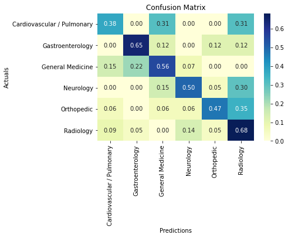

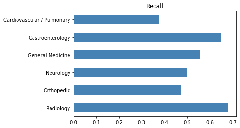

```python
#LL - evaluate metrics of the model trained with default hyperparameters
evaluate_metrics(multiclass_predictor, test_features.values, test_labels.values)
```

### Create model from the training job

After the training job is done, the model is not saved yet. Check training jobs and models in your SageMaker Console. To create a model from a training job, refer to the documentation for *[create_model API](https://boto3.amazonaws.com/v1/documentation/api/latest/reference/services/sagemaker.html#SageMaker.Client.create_model)*

```python
## create a primary container with the trained model
training_image = retrieve(framework="linear-learner", region=region, version="1.5-1")
model_data=multiclass_estimator.create_model().model_data
primary_container = {
     'Image': training_image,
     'ModelDataUrl': model_data
}
```

```
WARNING:sagemaker.image_uris:Defaulting to the only supported framework/algorithm version: 1. Ignoring framework/algorithm version: 1.5-1.
```

```python
## Prepare a model for hosting to run inference
 model_name = 'll-hhmodel-01' ## new model name
 create_model_response = sgmk_client.create_model(
     ModelName = model_name,
     ExecutionRoleArn = sgmk_role,
     PrimaryContainer = primary_container,
 )
```

### Inference Example

A simplified pipeline to process an Electronic Health Record Combine Textract, Comprehend Medical and SageMaker endpoint to process an electronic medical resport.

```python
from imp import reload
from util.Pipeline import extractTextract, extractMedical
```

### Step 1: Extract data from Textract

I have used 2 use cases below.

1- A medical report in English: please chose first document and uncomment the second one. If you chose this path after running the first code block below you can move to Step 2: Extract data from Comprehend Medical to skip the language detection and translation blocks.

2- A medical report in German: please chose second document and uncomment the first one

```
- first use Translate to create a English translation
```

```python
PDFprefix='hhtestdata' # bucket name if you use test data from s3- customize to your s3 if you test this code

# Check the 2 use cases seperately (you should chose either Use case 1 or Use case 2
# If you chose use case 1, you can skip the next few blocks and directly go to Step 2: Extract data from Comprehend Medical
# Use case 1 - English language report
fileName =  'sample_report_1.pdf'

# Use case 2 - German language report
#fileName =  'sample_report_2.pdf'

fileUploadPath = os.path.join("./data", fileName) # if you upload from working dir
#fileUploadPath = os.path.join(PDFprefix, fileName) # if you upload from a s3 bucket
print("EHR file to be processed is at ", fileUploadPath)

boto3.Session().resource("s3").Bucket(bucket_name).Object(fileName).upload_file(
    fileUploadPath
)

doc=extractTextract(bucket_name, fileName) # extract pdf file
```

```
EHR file to be processed is at  ./data/sample_report_1.pdf
job id is:  088487f22c8c278aed6726a79427b1a3d9c70220331f85ab5570c1c8022b26b9
```

```python
 # read full text
print("Total length of document is", len(doc.pages))
idx = 1
full_text = ""
for page in doc.pages:
    print(f"Results from page {idx}: \n", page.text)
    full_text += page.text
    idx = idx + 1
```

```
Total length of document is 2
Results from page 1:
 Discharge Summary
Name
Terri Hodosy
Birth Date
10/22/1962
Gender
female
Post Code
1826
Admission Date
01/01/2020
Discharge Date
01/20/2020
Medications
HISTORY: This 15-day-old female presents to Children's Hospital and transferred from Hospital
Emergency Department for further evaluation. Information is obtained in discussion with the mother
and the grandmother in review of previous medical records. This patient had the onset on the day of
presentation of a jelly-like red-brown stool started on Tuesday morning. Then, the patient was noted
to vomit after feeds. The patient was evaluated at Hospital with further evaluation with laboratory
data showing a white blood cell count elevated at 22.2; hemoglobin 14.1; sodium 138; potassium 7.2,
possibly hemolyzed; chloride 107; CO2 23; BUN 17; creatinine 1.2; and glucose of 50, which was
repeated and found to be stable in that range. The patient underwent a barium enema, which was
read by the radiologist as negative. The patient was transferred to Children's Hospital for further
evaluation after being given doses of ampicillin, cefotaxime, and Rocephin., PAST MEDICAL
HISTORY:, Further, the patient was born in Hospital. Birth weight was 6 pounds 4 ounces. There
was maternal hypertension. Mother denies group B strep or herpes. Otherwise, no past medical
history.,IMMUNIZATIONS: None today. MEDICATIONS: Thrush medicine identified as
lystatin.,ALLERGIES:, Denied., PAST SURGICAL HISTORY: Denied. SOCIAL HISTORY: ,Here
with mother and grandmother, lives at home. There is no smoking at home. FAMILY HISTORY:
None noted exposures., REVIEW OF SYSTEMS: The patient is fed Enfamil, bottle-fed. Has had
decreased feeding, has had vomiting, has had diarrhea, otherwise negative on the 10 plus systems
reviewed.,PHYSICAL EXAMINATION: VITAL SIGNS/GENERAL: On physical examination, the initial
temperature 97.5, pulse 140, respirations 48 on this 2 kg 15-day-old female who is small,
well-developed female, age appropriate., HEENT: Head is atraumatic and normocephalic with a soft
and flat anterior fontanelle. Pupils are equal, round, and reactive to light. Grossly conjugate.
Bilateral red reflex appreciated bilaterally. Clear TMs, nose, and oropharynx. There is a kind of
abundant thrush and white patches on the tongue. NECK: Supple, full, painless, and nontender
range of motion. CHEST: Clear to auscultation, equal, and stable. HEART: Regular without rubs
```

[output cut: 21 more lines]

```
was removed, and sterile bandage was placed. The fluid was sent to laboratory for further evaluation
(aunt and grandmother) were present throughout the period of time during this procedure and the
procedure was tolerated well. An i-STAT initially obtained showed somewhat of an acidosis with a
base excess of -12. A repeat i-STAT after a bolus of normal saline and a second bolus of normal
saline, her maintenance rate of D5 half showed a base excess of -11, which is slowly improving, but
not very fast. Based on the above having this patient consulted to the Hospitalist Service at 2326
hours of request, this patient was consulted to PICU with the plan that the patient need to have
continued IV fluids. Showing signs of dehydration, a third bolus of normal saline was provided, twice
maintenance D5 half was continued. The patient was admitted to the Hospitalist Service for
continued IV fluids. The patient maintains to have clear lungs, has been feeding well here in the
department, took virtually a whole small bottle of the appropriate formula. She has not had any
vomiting, is burping. The patient is admitted for continued close observation and rehydration due to
the working diagnoses of gastroenteritis, metabolic acidosis, and dehydration. Critical care time on
this patient is less than 30 minutes, exclusive, otherwise time has been spent evaluating this patient
according to this patient's care and admission to the Hospitalist Service.
```

```python
# detect languagge
comprehend_client = boto3.client(service_name="comprehend", region_name="us-east-1")
response = comprehend_client.detect_dominant_language(Text=full_text).get(
    "Languages", []
)
for language in response:
    print(
        f"Detected language is {language.get('LanguageCode', [])}, with a confidence score of {language.get('Score', [])}"
    )
```

```
Detected language is en, with a confidence score of 0.9918264746665955
```

```python
# if language is de then translate to en
if language.get('LanguageCode', [])=='de':
    translate = boto3.client(service_name='translate', region_name='us-east-1', use_ssl=True)
    result = translate.translate_text(Text=full_text[:5000], SourceLanguageCode="de", TargetLanguageCode="en")
    enFullText = result.get('TranslatedText')
    print('TranslatedText: ' + enFullText)
```

### Step 2: Extract data from Comprehend Medical

```python
if language.get('LanguageCode', [])=='de':
    comprehendResponse=extractMedical(enFullText)
else:
    comprehendResponse=extractMedical(doc)
df_cm=extractMC_v2(comprehendResponse[0]) # create dataframe with feature set
```

### Step 3: Organize the extracted json file into dataframe

```python
mclist, df_cm2=retrieve_mcList(df_cm, nFeature=40,threshold=0.8) # use same nfeatures and threshold as before
df_cm2=df_mc_generator_slim(df_cm2)
df_cm2
```

|  | ID | nontender | foreign body | edema | alert | murmur | chest pain | vomiting | hiatal hernia | distress | ... | fracture | lesion | ulceration | nausea | cough | tumor | soft | shortness of breath | injury | diabetes |
| --- | --- | --- | --- | --- | --- | --- | --- | --- | --- | --- | --- | --- | --- | --- | --- | --- | --- | --- | --- | --- | --- |
| 0 | 0 | 0.987771 | 0 | 0 | 0 | 0 | 0 | 0.998349 | 0 | 0 | ... | 0 | 0.99847 | 0 | 0 | 0 | 0 | 0.997684 | 0 | 0 | 0 |

1 rows × 38 columns

### Step 4: Prediction with the endpoint

```python
# Create an empty dataset with same feature list as in our dataset used to train
df_final=test_features.iloc[0:0,0:]
#print(df_final)

# chose from the comprehend medical extracted features only features as in the train dataset
df_final=df_final.append(df_cm2[df_cm2.columns.intersection(df_final.columns)])

df_final=df_final.fillna(0)
df_final=df_final.apply(pd.to_numeric, downcast='float', errors='coerce')
#print(df_final)
```

```python
# 1. predict with trained model
result=multiclass_predictor.predict(df_final.values) # in memory model during training
print(result)
```

```
[label {
  key: "predicted_label"
  value {
    float32_tensor {
      values: 4.0
    }
  }
}
label {
  key: "score"
  value {
    float32_tensor {
      values: 0.12450017035007477
      values: 0.029152095317840576
      values: 0.06447764486074448
      values: 0.12654690444469452
      values: 0.5679470896720886
      values: 0.07485228776931763
      values: 0.006244600284844637
      values: 0.0062791830860078335
    }
  }
}
]
```

```python
# create csv format input string to predict using endpoint
import json
#print(df_final.values)
s = json.dumps(df_final.values.tolist())
#print(s[0:])
td=s[0:]
td=td.replace('[', '')
td=td.replace(']', '')
print(td)
```

```
0.0, 0.0, 0.0, 0.9976842403411865, 0.0, 0.0, 0.0, 0.0, 0.0, 0.0, 0.0, 0.0, 0.0, 0.6807340383529663, 0.0, 0.0, 0.0, 0.0, 0.0, 0.0, 0.0, 0.0, 0.0, 0.0, 0.0, 0.0, 0.0, 0.0, 0.0, 0.0, 0.0, 0.0, 0.0, 0.0, 0.0, 0.0, 0.0, 0.0, 0.0, 0.0, 0.0, 0.0, 0.0, 0.0, 0.0, 0.0, 0.0, 0.0, 0.0, 0.0, 0.0, 0.0, 0.0, 0.0, …
```

```python
# a test record
#td='0.0, 0.0, 0.0, 0.0, 0.0, 0.6807340383529663, 0.0, 0.0, 0.0, 0.0, 0.0, 0.0, 0.0, 0.0, 0.0, 0.0, 0.0, 0.9984696507453918, 0.0, 0.0, 0.0, 0.0, 0.0, 0.0, 0.0, 0.0, 0.0, 0.0, 0.0, 0.0, 0.0, 0.0'

# 2. predict using the endpoint
endpoint = 'hhmulticlass'
runtime = boto3.Session().client('sagemaker-runtime')

# Send input data to get prediction via InvokeEndpoint API
response = runtime.invoke_endpoint(EndpointName=endpoint, ContentType='text/csv', Body=td)

# Unpack response
result = json.loads(response['Body'].read().decode())
print(result)
```

```
{'predictions': [{'score': [0.12450017035007477, 0.029152095317840576, 0.06447764486074448, 0.12654690444469452, 0.5679470896720886, 0.07485228776931763, 0.006244600284844637, 0.0062791830860078335], 'predicted_label': 4}]}
```

## Conclusion

At the end inference results showed the predicted classification which can be used for providing health recommendations.

## Clean up resources

### Delete the endpoint and configuration if needed

```python
multiclass_estimator.delete_endpoint(delete_endpoint_config=True)
```

### Delete the generated files S3 bucket files

```python
## Delete all the content in the emr-mtSample folder. Check S3 before deleting it
s3 = boto3.resource('s3')
bucket = s3.Bucket(bucket_name)
bucket.objects.filter(Prefix=bucket_prefix).delete()
```

```python
### Delete all the content in the PDF folder
bucket.objects.filter(Prefix=PDFprefix).delete()
```

### Best Practice:

1. Delete the buckets created from testing
2. Shut down your notebook instance if you are not planning to explore more